# Breast Cancer Data Analysis

Shiwani Limbu

2024-02-26

## [BRCA Subtypes](https://www.ncbi.nlm.nih.gov/books/NBK583808/)

### LumA

Luminal A tumors are characterized by the presence of ER and/or PR and the absence of HER2, and have a low expression of cell proliferation marker Ki-67 (less than 20%) (https://www.ncbi.nlm.nih.gov/books/NBK583808). Clinically they are low grade, slow growing, and have the best prognosis with less incidence of relapse and higher survival rate.

### LumB

Luminal B tumors are of higher grade and worse prognosis compared to Luminal A. They are ER positive and can be PR negative and have a high expression of Ki67 (greater than 20%) (https://www.ncbi.nlm.nih.gov/books/NBK583808). They are generally of intermediate/high histologic grade. These tumors may benefit from hormonal therapy along with chemotherapy. The elevated Ki67 makes them grow faster than luminal A and worse prognosis.

### Her2

The HER2-positive group constitutes 10–15% of breast cancers and is characterized by high HER2 expression with absence of ER and PR. They grow faster than the luminal ones and the prognosis has improved after the introduction of HER2-targeted therapies. The HER2-positive subtype is more aggressive and fast-growing. Within this, two subgroups can be distinguished: luminal HER2 (E+, PR+, HER2+ and Ki-67:15–30%) and HER2-enriched (HER2+, E-, PR-, Ki-67>30%) (https://www.ncbi.nlm.nih.gov/books/NBK583808). They have a worse prognosis compared to luminal tumors

### Triple-negative

Triple-negative breast cancer is ER-negative, PR-negative, and HER2-negative (https://www.ncbi.nlm.nih.gov/books/NBK583808). They constitute about 20% of all breast cancers. It is most common among women under 40 years of age, and in African-American women. The TNBC subtype is further classified into several additional subgroups including basal-like (BL1 and BL2), claudin-low, mesenchymal (MES), luminal androgen receptor (LAR), and immunomodulatory (IM), the first two being the most frequent with 50–70% and 20–30% of cases. Moreover, each of these has unique clinical outcomes, phenotypes, and pharmacological sensitivities. TNBC presents an aggressive behavior and 80% of breast cancer tumors (tumor suppressor gene BRCA1 and BRCA2) belong to this group.

##Gene differential expression analysis

```r
cancer_type = "TCGA-BRCA"
```

```r
library(TCGAbiolinks)
library(ggplot2)
library(MultiAssayExperiment)
library(dplyr)
library(openxlsx)
```

Download gene Primary tumor and Solid Tissue Normal Data

```r
# Download tumor sample Gene expression
query_exp_tumor <- GDCquery(
  project = cancer_type,
  data.category = "Transcriptome Profiling",
  data.type = "Gene Expression Quantification",
  workflow.type = "STAR - Counts",
  sample.type = c("Primary Tumor")
)

GDCdownload(query_exp_tumor)
exp_tumor <- GDCprepare(
  query = query_exp_tumor
)


# Download normal sample Gene expression
query_exp_normal <- GDCquery(
  project = cancer_type,
  data.category = "Transcriptome Profiling",
  data.type = "Gene Expression Quantification",
  workflow.type = "STAR - Counts",
  sample.type = c("Solid Tissue Normal")
)

GDCdownload(query_exp_normal)
exp_normal <- GDCprepare(
  query = query_exp_normal
)
```

Pull BRCA subtype data

```r
subtype = "LumB"
clinical_data <- GDCquery_clinic(project = "TCGA-BRCA", type = "clinical")

metadata <- colData(exp_tumor) # contains dataframe with PAM50 tumor classifications and other clinical data for each sample
subtype_samples <- metadata[!is.na(metadata$paper_BRCA_Subtype_PAM50) & metadata$paper_BRCA_Subtype_PAM50 == subtype,]

# It is important to note that sample ids in exp_tumor is large ids with extra characters and samples$bcr_patient_barcode
# has tructued id format. Therefore to match these and pull subtype sample expression data, we need following

matched_columns <- sapply(colnames(exp_tumor), function(column_name) {
  any(sapply(subtype_samples$bcr_patient_barcode, function(truncated_id) {
    grepl(truncated_id, column_name)
  }))
})

exp_tumor_subtype <- exp_tumor[, matched_columns]

dim(exp_tumor_subtype)
```

```
## [1] 60660   209
```

Here, we have total 209 LumB samples downloaded from TCGA.

###Data preprocessing Remove low correlated outlier samples

```r
exp_preprocessed_tumor <- TCGAanalyze_Preprocessing(
  object = exp_tumor_subtype,
  cor.cut = 0.4,
  datatype = "unstranded",
  filename = "correlation_tumor.png"
)
```

```
## Number of outliers: 0
```

```r
dim(exp_preprocessed_tumor)
```

```
## [1] 60660   209
```

This step found 0 samples with low correlation (cor.cut = 0.4) that can be identified as possible outliers. Image below shows that most of the samples have correlation ~0.8 or higher.

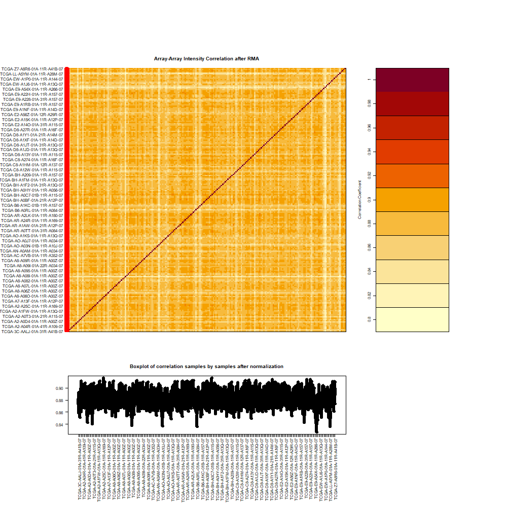

```r
knitr::include_graphics("correlation_tumor.png")
```

Lets do the same for Solid Tissue Normal samples

```r
exp_preprocessed_normal <- TCGAanalyze_Preprocessing(
  object = exp_normal,
  cor.cut = 0.4,
  datatype = "unstranded",
  filename = "correlation_normal.png"
)
```

```
## Number of outliers: 0
```